# TP CAUSALITÉ (Corrigé)

TP CAUSALITÉ (Corrigé)

# **Partie 1. Inverse Probability Treatment Weighting (IPTW)**

##### 1.1) Charger la base de données *hosmer.xlsx*

```r
library(readxl)
hosmer <- read_excel("hosmer.xlsx")
hosmer <- as.data.frame(hosmer)
# Afficher la structure du jeu de données (variables, types, etc.)
str(hosmer)
```

```
## 'data.frame':    189 obs. of  10 variables:
##  $ Y   : num  2523 2551 2557 2594 2600 ...
##  $ T   : num  0 0 1 1 1 0 0 0 1 1 ...
##  $ ID  : num  85 86 87 88 89 91 92 93 94 95 ...
##  $ LWT : num  182 155 105 108 107 124 118 103 123 113 ...
##  $ AGE : num  19 33 20 21 18 21 22 17 29 26 ...
##  $ RACE: chr  "2" "3" "1" "1" ...
##  $ PTL : chr  "0" "0" "0" "0" ...
##  $ HT  : chr  "0" "0" "0" "0" ...
##  $ UI  : chr  "1" "0" "0" "1" ...
##  $ FVT : chr  "0" "3" "1" "2" ...
```

```r
# Afficher les premières lignes du jeu de données
head(hosmer)
```

```
##      Y T ID LWT AGE RACE PTL HT UI FVT
## 1 2523 0 85 182  19    2   0  0  1   0
## 2 2551 0 86 155  33    3   0  0  0   3
## 3 2557 1 87 105  20    1   0  0  0   1
## 4 2594 1 88 108  21    1   0  0  1   2
## 5 2600 1 89 107  18    1   0  0  1   0
## 6 2622 0 91 124  21    3   0  0  0   0
```

##### 1.2) À l’aide de la fonction *port* du package *RISCA*, vérifier l’hypothèse de positivité.

[figure not shown]

```r
library(RISCA)


port(group = "T",
     cov.quanti = c("AGE", "LWT"),
     cov.quali = c("RACE", "HT"),
     data = hosmer, alpha = 0.05, beta = 0.05, gamma = 1)
```

```
## No potential positivity violation identified.
```

Aux seuils **alpha=0.05** et **beta=0.05**, la fonction ne signale aucune violation de la positivité.

```r
port(group = "T",
     cov.quanti = c("AGE", "LWT"),
     cov.quali = c("RACE", "HT"),
     data = hosmer, alpha = 0.2, beta = 0.3, gamma = 1)
```

```
## In order for potential confounding factors to be correctly handled, one must ensure that individual characteristics are sufficiently frequent in each group. We have observed that :
##  - individuals of categories 3 on variable RACE (N=67, 35.4% of the sample), have a 17.9% chance of being exposed.
```

On constate que pour les seuils **alpha=0.2** et **beta=0.3**, la fonction signale une violation de la positivité: le sous-groupe des individus de catégorie **RACE=3** est suffisamment grand pour être considéré comme problématique ($35.4\% >$ **beta** $=30\%$), et leur probabilité d’être exposés est trop faible ($17.9\% <$ **alpha** $=20\%$).

##### 1.2) Construire le modèle d’exposition par régression logistique multivariée, et extraire le score de propension pour chaque individu.

```r
library(WeightIt)

# Les modèles avec splines ou polynômes peuvent être facilement intégrés en ajoutant des termes bs(), ns() ou poly() dans la formule.
IPW_Model <- weightit(T ~ AGE +  RACE  + LWT:RACE + HT,
              method = "glm", estimand = "ATE",
              data = hosmer,
              stabilize = TRUE)

# Extraire les scores de propension estimés P(T=1 | W) pour chaque individu
head(IPW_Model$ps)
```

```
##         1         2         3         4         5         6
## 0.3495527 0.1565440 0.6776682 0.6582416 0.6881850 0.1848738
```

##### 1.3) Vérifier l’hypothèse de positivité en traçant la distribution du score de propension dans les deux groupes de traitement.

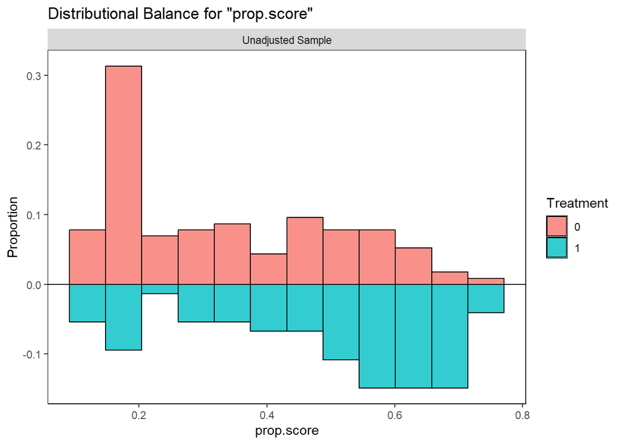

```r
library(cobalt)
# Histogramme des scores de propension
bal.plot(IPW_Model, var.name = "prop.score", which = "un",
         type = "histogram", mirror = TRUE)
```

On peut également afficher les distributions sous forme de courbes de densité, ce qui permet de mieux visualiser le recouvrement :

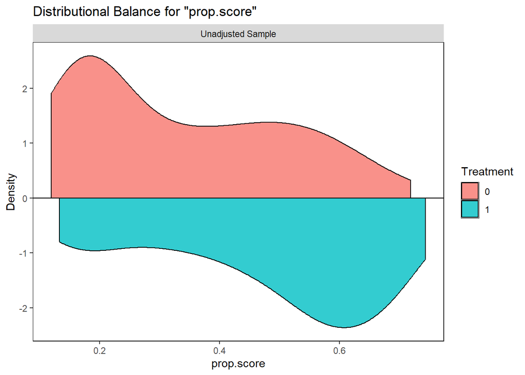

```r
# Densité des scores de propension

bal.plot(IPW_Model, var.name = "prop.score", which = "un",
         type = "density", mirror = TRUE)
```

##### 1.4) Calculer (extraire) les poids de probabilité inverse pour chaque individu.

```r
# Extraire les poids estimés pour chaque individu
IPWeights <- IPW_Model$weights
head(IPWeights)
```

```
##         1         2         3         4         5         6
## 0.9354572 0.7213958 0.5777671 0.5948186 0.5689377 0.7464680
```

##### 1.5) Vérifier la qualité d’ajustement du modèle de score de propension en calculant la différence standardisée des moyennes (SMD).

Une règle empirique pour déterminer un équilibre adéquat est que la SMD (en valeur absolue) de toutes les covariables soit contrôlée en dessous de 0.1.

```r
bal.tab(IPW_Model, stats = "mean.diffs", un = TRUE,s.d.denom = "pooled")
```

```
## Balance Measures
##                Type Diff.Un Diff.Adj
## prop.score Distance  0.8775  -0.0194
## AGE         Contin. -0.0913   0.0040
## RACE_1       Binary  0.3201  -0.0069
## RACE_2       Binary -0.0040   0.0009
## RACE_3       Binary -0.3161   0.0060
## HT           Binary  0.0067  -0.0086
## LWT         Contin. -0.0884  -0.0302
##
## Effective sample sizes
##            Control Treated
## Unadjusted  115.     74.
## Adjusted    103.83   52.78
```

Avant pondération, plusieurs covariables présentent un déséquilibre notable entre les groupes fumeuses et non-fumeuses. Le score de propension lui-même affiche une SMD de 0.88, et les indicatrices RACE_1 (0.32) et RACE_3 (-0.32) montrent un déséquilibre marqué. Les autres covariables (AGE, LWT, RACE_2, HT) sont en revanche déjà proches de l’équilibre avec des |SMD| inférieures à 0.10. Après pondération IPW, toutes les valeurs de SMD passent largement en dessous du seuil de 0.10 en valeur absolue. Cela confirme que le modèle de score de propension a correctement équilibré les covariables entre les groupes de traitement, et que la pseudo-population pondérée peut être utilisée pour estimer l’effet causal.

On peut également visualiser cet équilibre à l’aide d’un Love plot, qui affiche la SMD absolue pour chaque covariable avant et après pondération, avec une ligne verticale en pointillés au seuil choisi.

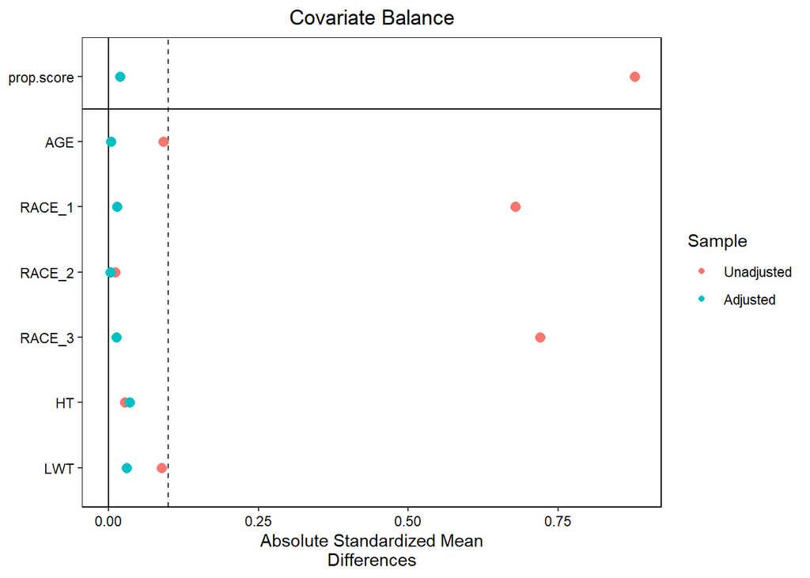

```r
love.plot(IPW_Model,
          binary = "std",
          thresholds = 0.1,
          abs = TRUE,
          un = TRUE)
```

Ce Love plot affiche la différence standardisée absolue (SMD) pour chaque covariable avant pondération (points roses) et après pondération IPW (points bleus). La ligne verticale en pointillés marque le seuil de 0.1.

Avant pondération, plusieurs covariables dépassent le seuil de 0.1. Après pondération IPW, tous les points bleus se situent bien en deçà du seuil de 0.1, proches de zéro. Cela confirme que la pondération a efficacement équilibré les covariables entre les groupes de traitement.

##### 1.6) Calculer l’effet causal moyen (ATE) en utilisant la différence des moyennes pondérées.

```r
y1 <- weighted.mean(hosmer$Y[hosmer$T == 1], IPWeights[hosmer$T == 1])
y0 <- weighted.mean(hosmer$Y[hosmer$T == 0], IPWeights[hosmer$T == 0])
ATE <- y1 - y0
ATE
```

```
## [1] -361.3353
```

Cette méthode donne l’estimation ponctuelle de l’ATE mais ne fournit pas d’erreur standard ni d’intervalle de confiance.

##### 1.7) Calculer l’effet causal moyen (ATE) en estimant un modèle de régression pondéré de $Y$ sur $T$.

On estime un modèle linéaire pondéré :

```r
ATE_glm <- glm_weightit(Y ~ T,
                         data = hosmer,
                         family = gaussian,
                         weightit = IPW_Model,
                         vcov = "BS",
                         R = 100)
summary(ATE_glm, ci = TRUE, level = 0.95)
```

```
##
## Call:
## glm_weightit(formula = Y ~ T, data = hosmer, family = gaussian,
##     weightit = IPW_Model, vcov = "BS", R = 100)
##
## Coefficients:
##             Estimate Std. Error z value Pr(>|z|)   2.5 %  97.5 %
## (Intercept)  3110.25      71.36  43.583   <1e-06 2970.38 3250.12 ***
## T            -361.34     149.12  -2.423   0.0154 -653.61  -69.06 *
## Standard error: traditional bootstrap
```

L’intercept $\hat{\gamma}_0 = 3110.2$ correspond à la moyenne pondérée du poids de naissance chez les non fumeuses. Le coefficient $\hat{\gamma}_1 = -361.3$ correspond à l’ATE.

L’estimation donne un ATE de **−361.3 grammes**, similaire à ce qu’on a obtenu dans la question 1.6. Cela signifie qu’après ajustement sur les facteurs de confusion par pondération IPW, le tabagisme maternel pendant la grossesse entraîne en moyenne une diminution du poids de naissance d’environ 361.3 grammes par rapport aux mères non fumeuses. Le signe négatif est cohérent avec les connaissances médicales sur l’effet délétère du tabac sur la croissance fœtale.

# **Partie 2. G-computation**

##### 2.1) Construire le modèle d’outcome par régression linéaire multivariée.

```r
outcome_model <- glm(formula = Y ~ T + AGE  + RACE + LWT+RACE:LWT+RACE:T,
                     data = hosmer, family = gaussian)
```

##### 2.2) Créer deux jeux de données contrefactuels, `hosmer0` et `hosmer1`, dans lesquels tous les sujets sont respectivement considérés comme non traités et traités.

```r
hosmer0 <- hosmer
hosmer1 <- hosmer
hosmer0$T <- 0  # Tous les sujets sont passés en non traités
hosmer1$T <- 1  # Tous les sujets sont passés en traités
```

##### 2.3) Utiliser le modèle d’outcome pour prédire la réponse individuelle $\hat{\mathbb{E}}(Y \mid T, W)$ pour chaque sujet dans `hosmer0` et dans `hosmer1`.

```r
E0i <- predict(outcome_model, newdata = hosmer0, type = "response")
E1i <- predict(outcome_model, newdata = hosmer1, type = "response")
```

##### 2.4) Calculer la moyenne standardisée (marginale) de l’outcome dans `hosmer0` et `hosmer1` :

```r
E0 <- mean(E0i)
E1 <- mean(E1i)
```

##### 2.5) Calculer l’effet moyen du traitement (ATE) :

```r
ATE <- E1 - E0
ATE
```

```
## [1] -369.0026
```

##### 2.6) Calculer l’effet moyen du traitement (ATE) en utilisant la fonction

`standardize_glm` du package *stdReg2*.

```r
library(stdReg2)
STD_GLM_Model <- standardize_glm(formula = Y ~ T + AGE  + RACE+ RACE:T + RACE:LWT,
                                  data = hosmer, family = "gaussian",
                                  values = list(T = c(0, 1)), reference = 0,
                                  ci_level = 0.95,
                                  contrasts = "difference")
ATE <- STD_GLM_Model$res_contrast[[2]]$est_table$Estimate[2]

IC_ATE <- c(STD_GLM_Model$res_contrast[[2]]$est_table$lower.0.95[2],
            STD_GLM_Model$res_contrast[[2]]$est_table$upper.0.95[2])

#AVERAGE TREATMENT EFFECT
ATE
```

```
## [1] -369.0026
```

```r
#95% CONFIDENCE INTERVAL FOR ATE
IC_ATE
```

```
## [1] -601.7092 -136.2959
```

On retrouve un ATE de **−369 grammes**, très proche de ce qu’on a obtenu par IPTW (-361.3).

##### 2.7) En utilisant la fonction `standardize` du package *stdReg2*, calculer l’ATE et son intervalle de confiance à 95 % par bootstrap.

```r
predict_glm <- function(object, newdata) {
  predict(object, newdata = newdata, type = "response")
}

STD_Model_BOOTSTRAP <- standardize(
  fitter = "glm",
  arguments = list(
    formula = Y ~ T + AGE + RACE + RACE:T + RACE:LWT,
    family = gaussian,
    data = hosmer
  ),
  predict_fun = predict_glm,
  data = hosmer,
  values = list(T = c(0, 1)),
  B = 100,
  ci_level = 0.95,
  contrasts = "difference",
  reference = 0,
  progressbar=FALSE
)


ATE <- STD_Model_BOOTSTRAP$res_contrast[[2]]$est_table$Estimate[2]
IC_ATE <- c(STD_Model_BOOTSTRAP$res_contrast[[2]]$est_table$lower.0.95[2],
            STD_Model_BOOTSTRAP$res_contrast[[2]]$est_table$upper.0.95[2])

#AVERAGE TREATMENT EFFECT
ATE
```

```
## [1] -369.0026
```

```r
#95% CONFIDENCE INTERVAL FOR ATE
IC_ATE
```

```
## [1] -648.7123 -124.0396
```

Les intervalles de confiance affichés sont des intervalles de confiance bootstrap percentile : ils sont obtenus en prenant les quantiles 2.5 % et 97.5 % de la distribution empirique des $B = 100$ ATE bootstrappés.

On retrouve bien un ATE de **−369 grammes**, exactement pareil que celui obtenu avec `standardize_glm`.

## Estimateur Doublement Robuste (Doubly Robust)

##### 2.8) En utilisant la fonction `standardize_glm_dr` du package *stdReg2*,calculer l’estimateur doublement robuste de ATE.

```r
STD_GLM_Model_DR <- standardize_glm_dr(
  formula_outcome  = Y ~ T + AGE + RACE + RACE:T + RACE:LWT,
  formula_exposure = T ~ AGE + RACE + RACE:LWT,
  data = hosmer,
  family_outcome   = "gaussian",
  family_exposure  = "binomial",
  values = list(T = c(0,1)),
  reference = 0,
  ci_level = 0.95,
  contrasts = "difference"
)

ATE_DR <- STD_GLM_Model_DR$res_contrast[[2]]$est_table[2]$Estimate[2]
IC_ATE_DR <- c(STD_GLM_Model_DR$res_contrast[[2]]$est_table$lower.0.95[2],
               STD_GLM_Model_DR$res_contrast[[2]]$est_table$upper.0.95[2])

# Average Treatment Effect (Doubly Robust)
ATE_DR
```

```
## [1] -368.6661
```

```r
# Intervalle de confiance à 95%
IC_ATE_DR
```

```
## [1] -599.6677 -137.6644
```

**Remarque** : la propriété de double robustesse de cet estimateur n’est garantie que si le GLM d’outcome utilise une fonction de lien canonique (identité pour la famille gaussienne, logit pour la binomiale, log pour la Poisson, etc.). Lorsqu’on spécifie l’argument `family_outcome`, la fonction `standardize_glm_dr` utilise par défaut le lien canonique associé à cette famille.

On retrouve un ATE de **−368.6661 grammes**, très proche de ce qu’on avait obtenu avant par IPTW et par `standardize_glm`.

## G-computation pour des données de survie

##### 2.9) Charger le jeu de données `dataDIVAT2`, et afficher les premières lignes.

```r
library(RISCA)
data("dataDIVAT2")
# Afficher les premières lignes du jeu de données
head(dataDIVAT2)
```

```
##   age hla retransplant ecd     times failures
## 1  30   0            1   1 7.0116359        0
## 2  42   0            1   1 3.9370294        1
## 3  52   0            1   0 7.0006845        0
## 4  43   0            1   0 1.0075291        0
## 5  30   0            1   0 4.9965777        0
## 6  63   0            1   0 0.9089665        1
```

##### 2.10) À l’aide de la fonction `port` du package *RISCA*, vérifier l’hypothèse de positivité.

```r
port(group = "ecd",
     cov.quanti = c("age"),
     cov.quali = c("retransplant", "hla"),
     data = dataDIVAT2,
     alpha = 0.05, beta = 0.05, gamma = 1)
```

```
## In order for potential confounding factors to be correctly handled, one must ensure that individual characteristics are sufficiently frequent in each group. We have observed that :
##  - individuals with values less than 40 on variable age (N=446, 24.3% of the sample), have a 4.0% chance of being exposed.
```

##### 2.11) Vérifier l’hypothèse de positivité en traçant la distribution des scores de propension.

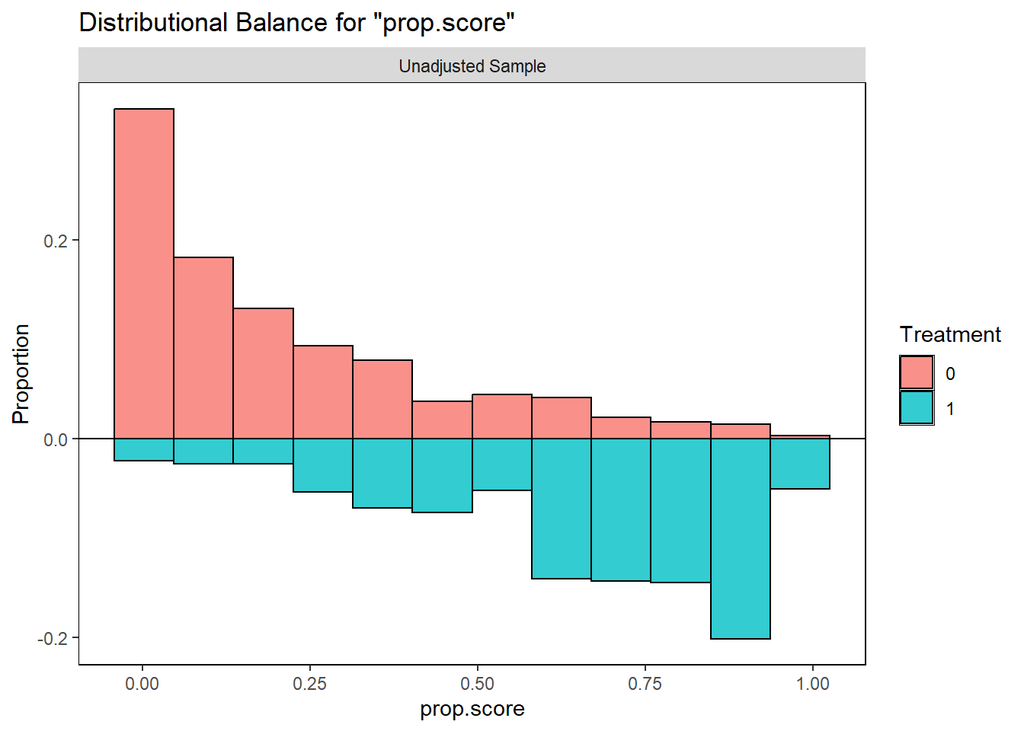

```r
library(WeightIt)
library(cobalt)

IPW_Model <- weightit(ecd ~ age + hla + retransplant,
                      method = "glm", estimand = "ATE",
                      data = dataDIVAT2,
                      stabilize = TRUE)

bal.plot(IPW_Model, var.name = "prop.score", which = "un",
         type = "histogram", mirror = TRUE)
```

La fonction `port()` signale une violation potentielle de la positivité : parmi les individus de moins de 40 ans (N=446, soit $24,3\%$ de l’échantillon), seuls $4,0 \%$ sont exposés. L’histogramme miroir des scores de propension suggère pourtant un recouvrement satisfaisant sur l’ensemble de la plage $[0,1]$, sans zone vide. Cette apparente divergence s’explique par le fait que les deux outils n’évaluent pas la positivité au même niveau : `bal.plot` la vérifie marginalement sur le score de propension (un résumé scalaire des covariables), tandis que `port()` la vérifie conditionnellement aux covariables d’origine. Un score commun aux deux groupes peut ainsi masquer des sous-groupes où l’exposition reste rare.

##### 2.12) Construire le modèle d’outcome de survie en utilisant la fonction `coxph` du package *survival*.

```r
library(survival)
outcome_model_survival <- coxph(
  formula = Surv(times, failures) ~ ecd + age + hla + retransplant,
  data = dataDIVAT2
)
```

##### 2.13) Créer deux jeux de données contrefactuels, `dataDIVAT2_0` et `dataDIVAT2_1`, dans lesquels tous les sujets sont respectivement considérés comme non traités et traités.

```r
dataDIVAT2_0 <- dataDIVAT2
dataDIVAT2_1 <- dataDIVAT2
dataDIVAT2_0$ecd <- 0  # Tous les sujets sont passés en non traités
dataDIVAT2_1$ecd <- 1  # Tous les sujets sont passés en traités
```

##### 2.14) Utiliser le modèle d’outcome pour prédire la fonction de survie en $t \in {1,2,3,...,17}$, $\hat{S}(t \mid A, W)$, pour chaque sujet dans `dataDIVAT2_0` et dans `dataDIVAT2_1`.

```r
Surv0i <- summary(survfit(outcome_model_survival, newdata = dataDIVAT2_0), times = c(1:17))$surv
Surv1i <- summary(survfit(outcome_model_survival, newdata = dataDIVAT2_1), times = c(1:17))$surv

#view(Surv0i)
#view(Surv0i)
```

##### 2.15) Calculer la fonction de survie standardisée (marginale) dans chaque $t \in \{1,2,3,...,17\}$ dans `dataDIVAT2_0` et `dataDIVAT2_1`, en utilisant la fonction `rowMeans` permettant de faire la moyenne par ligne d’une matrice :

```r
Surv0 <- rowMeans(Surv0i)
Surv1 <- rowMeans(Surv1i)
```

##### 2.16) Calculer la *standardized survival difference* dans chaque $t \in \{1,2,3,...,17\}$.

```r
STD_SURV_DIFF <- Surv1 - Surv0
STD_SURV_DIFF
```

```
##  [1] -0.04326380 -0.05981109 -0.07238810 -0.08876973 -0.10259953 -0.11919882
##  [7] -0.13121677 -0.14445710 -0.15409492 -0.16306858 -0.16680940 -0.17227117
## [13] -0.17653809 -0.17941023 -0.17980000 -0.17587083 -0.16850221
```

##### 2.17) Calculer la *standardized survival difference* dans chaque $t \in \{1,2,3,...,17\}$ en utilisant la fonction `standardize_coxph` du package *stdReg2*.

```r
library(stdReg2)
STD_COXPH_Model <- standardize_coxph(
  formula = Surv(times, failures) ~ ecd + age + hla + retransplant,
  data = dataDIVAT2,
  times = c(1:17),
  values = list(ecd = c(0, 1)),
  reference = 0,
  ci_level = 0.95,
  contrasts = "difference"
)

# Extraire toutes les estimations de chaque time point entre 1 et 17
STD_SURV_DIFF <- sapply(STD_COXPH_Model$res_contrast[[2]]$est_table,
                    function(x) x$Estimate[2])


# Extraire tous les IC à 95% de chaque time point entre 1 et 17


IC_STD_SURV_DIFF <- data.frame(
  lower= sapply(STD_COXPH_Model$res_contrast[[2]]$est_table,
         function(x) x$lower.0.95[2]),
  upper=sapply(STD_COXPH_Model$res_contrast[[2]]$est_table,
         function(x) x$`upper 0.95`[2])
)

# Standardized survival difference
STD_SURV_DIFF
```

```
##  [1] -0.04324329 -0.05978875 -0.07236446 -0.08874437 -0.10257260 -0.11917075
##  [7] -0.13118736 -0.14442587 -0.15406434 -0.16303773 -0.16677918 -0.17224013
## [13] -0.17650919 -0.17938294 -0.17977765 -0.17585746 -0.16849507
```

```r
# 95% CONFIDENCE INTERVAL FOR Standardized survival difference
IC_STD_SURV_DIFF
```

```
##          lower       upper
## 1  -0.06113483 -0.02535175
## 2  -0.08391637 -0.03566113
## 3  -0.10180575 -0.04292317
## 4  -0.12504661 -0.05244213
## 5  -0.14483971 -0.06030549
## 6  -0.16819179 -0.07014971
## 7  -0.18529443 -0.07708029
## 8  -0.20400137 -0.08485037
## 9  -0.21775242 -0.09037625
## 10 -0.23059405 -0.09548140
## 11 -0.23583082 -0.09772754
## 12 -0.24351447 -0.10096578
## 13 -0.24949707 -0.10352131
## 14 -0.25336967 -0.10539621
## 15 -0.25363274 -0.10592256
## 16 -0.24758425 -0.10413067
## 17 -0.23729348 -0.09969665
```

##### 2.18) En utilisant la fonction `plot` du package *stdReg2*, tracer les courbes de survies dans les deux groupes de traitements ainsi que la standardized difference.

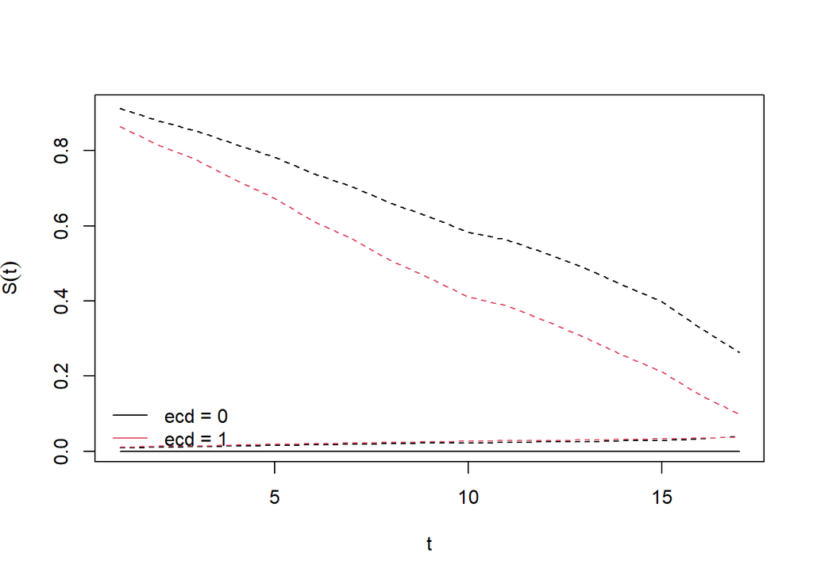

```r
###courbes de survies dans les deux groupes de traitements###

plot(x=STD_COXPH_Model,
     legendpos = "bottomleft")
```

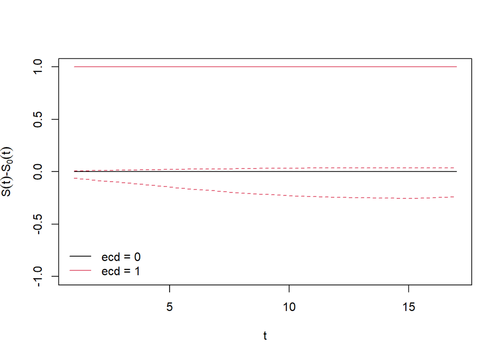

```r
###Standardized difference###

 plot(x=STD_COXPH_Model,
      contrast="difference",
      reference=0,
    legendpos = "bottomleft")
```

## Références

<sup>1</sup> Public Health England. *SARS-CoV-2 variants of concern and variants under investigation in England: Technical Briefing 20*, Table 5. [[Link]](https://assets.publishing.service.gov.uk/media/610d031f8fa8f506aab17866/Technical_Briefing_20.pdf)

<sup>2</sup> National Center for Health Statistics. *NHANES I - Epidemiologic Followup Study (NHEFS)*. [[Link]](https://wwwn.cdc.gov/nchs/nhanes/nhefs/)

<sup>3</sup> Zhou T, Tong G, Li F, Thomas LE. *PSweight: Propensity Score Weighting for Causal Inference with Observational Studies and Randomized Trials*. R package. [[Link]](https://cran.r-project.org/web/packages/PSweight/index.html)

<sup>4</sup> Noah Greifer *WeightIt: Weighting for Covariate Balance in Observational Studies*. R package. [[Link]](https://cran.r-project.org/web/packages/WeightIt/index.html)

<sup>5</sup> Noah Greifer *Covariate Balance Tables and Plots: A Guide to the cobalt Package*. R package. [[Link]](https://cran.r-project.org/web/packages/cobalt/vignettes/cobalt.html)